# Assignment #4

2026-06-14

## R Markdown

##First lets load the data

```r
mydata <- read.csv("Pharmaceuticals.csv")
head.data <- head(mydata)
str(mydata)
```

```
## 'data.frame':    21 obs. of  14 variables:
##  $ Symbol               : chr  "ABT" "AGN" "AHM" "AZN" ...
##  $ Name                 : chr  "Abbott Laboratories" "Allergan, Inc." "Amersham plc" "AstraZeneca PLC" ...
##  $ Market_Cap           : num  68.44 7.58 6.3 67.63 47.16 ...
##  $ Beta                 : num  0.32 0.41 0.46 0.52 0.32 1.11 0.5 0.85 1.08 0.18 ...
##  $ PE_Ratio             : num  24.7 82.5 20.7 21.5 20.1 27.9 13.9 26 3.6 27.9 ...
##  $ ROE                  : num  26.4 12.9 14.9 27.4 21.8 3.9 34.8 24.1 15.1 31 ...
##  $ ROA                  : num  11.8 5.5 7.8 15.4 7.5 1.4 15.1 4.3 5.1 13.5 ...
##  $ Asset_Turnover       : num  0.7 0.9 0.9 0.9 0.6 0.6 0.9 0.6 0.3 0.6 ...
##  $ Leverage             : num  0.42 0.6 0.27 0 0.34 0 0.57 3.51 1.07 0.53 ...
##  $ Rev_Growth           : num  7.54 9.16 7.05 15 26.81 ...
##  $ Net_Profit_Margin    : num  16.1 5.5 11.2 18 12.9 2.6 20.6 7.5 13.3 23.4 ...
##  $ Median_Recommendation: chr  "Moderate Buy" "Moderate Buy" "Strong Buy" "Moderate Sell" ...
##  $ Location             : chr  "US" "CANADA" "UK" "UK" ...
##  $ Exchange             : chr  "NYSE" "NYSE" "NYSE" "NYSE" ...
```

```r
summary(mydata)
```

```
##     Symbol              Name             Market_Cap          Beta
##  Length:21          Length:21          Min.   :  0.41   Min.   :0.1800
##  Class :character   Class :character   1st Qu.:  6.30   1st Qu.:0.3500
##  Mode  :character   Mode  :character   Median : 48.19   Median :0.4600
##                                        Mean   : 57.65   Mean   :0.5257
##                                        3rd Qu.: 73.84   3rd Qu.:0.6500
##                                        Max.   :199.47   Max.   :1.1100
##     PE_Ratio          ROE            ROA        Asset_Turnover    Leverage
##  Min.   : 3.60   Min.   : 3.9   Min.   : 1.40   Min.   :0.3    Min.   :0.0000
##  1st Qu.:18.90   1st Qu.:14.9   1st Qu.: 5.70   1st Qu.:0.6    1st Qu.:0.1600
##  Median :21.50   Median :22.6   Median :11.20   Median :0.6    Median :0.3400
##  Mean   :25.46   Mean   :25.8   Mean   :10.51   Mean   :0.7    Mean   :0.5857
##  3rd Qu.:27.90   3rd Qu.:31.0   3rd Qu.:15.00   3rd Qu.:0.9    3rd Qu.:0.6000
##  Max.   :82.50   Max.   :62.9   Max.   :20.30   Max.   :1.1    Max.   :3.5100
##    Rev_Growth    Net_Profit_Margin Median_Recommendation   Location
##  Min.   :-3.17   Min.   : 2.6      Length:21             Length:21
##  1st Qu.: 6.38   1st Qu.:11.2      Class :character      Class :character
##  Median : 9.37   Median :16.1      Mode  :character      Mode  :character
##  Mean   :13.37   Mean   :15.7
##  3rd Qu.:21.87   3rd Qu.:21.1
##  Max.   :34.21   Max.   :25.5
##    Exchange
##  Length:21
##  Class :character
##  Mode  :character
##
##
##
```

##Selecting just the numerical variables

```r
mydata.num <- mydata[,3:11]
```

##Now I am going to standardize the numerical variables

```r
mydata.scaled <- scale(mydata.num)
summary(mydata.scaled)
```

```
##    Market_Cap           Beta            PE_Ratio            ROE
##  Min.   :-0.9768   Min.   :-1.3466   Min.   :-1.3404   Min.   :-1.4515
##  1st Qu.:-0.8763   1st Qu.:-0.6844   1st Qu.:-0.4023   1st Qu.:-0.7223
##  Median :-0.1614   Median :-0.2560   Median :-0.2429   Median :-0.2118
##  Mean   : 0.0000   Mean   : 0.0000   Mean   : 0.0000   Mean   : 0.0000
##  3rd Qu.: 0.2762   3rd Qu.: 0.4841   3rd Qu.: 0.1495   3rd Qu.: 0.3450
##  Max.   : 2.4200   Max.   : 2.2758   Max.   : 3.4971   Max.   : 2.4597
##       ROA          Asset_Turnover       Leverage          Rev_Growth
##  Min.   :-1.7128   Min.   :-1.8451   Min.   :-0.74966   Min.   :-1.4971
##  1st Qu.:-0.9047   1st Qu.:-0.4613   1st Qu.:-0.54487   1st Qu.:-0.6328
##  Median : 0.1289   Median :-0.4613   Median :-0.31449   Median :-0.3621
##  Mean   : 0.0000   Mean   : 0.0000   Mean   : 0.00000   Mean   : 0.0000
##  3rd Qu.: 0.8430   3rd Qu.: 0.9225   3rd Qu.: 0.01828   3rd Qu.: 0.7693
##  Max.   : 1.8389   Max.   : 1.8451   Max.   : 3.74280   Max.   : 1.8862
##  Net_Profit_Margin
##  Min.   :-1.99560
##  1st Qu.:-0.68504
##  Median : 0.06168
##  Mean   : 0.00000
##  3rd Qu.: 0.82364
##  Max.   : 1.49416
```

##I had to standardize the numerical variables prior to clustering because the variables were measured on very different scale. For example, you had market cap being measured in billion of dollars and beta values that were less than 2.

##Now we need to determine the number of clusters using wss values and elbow plot

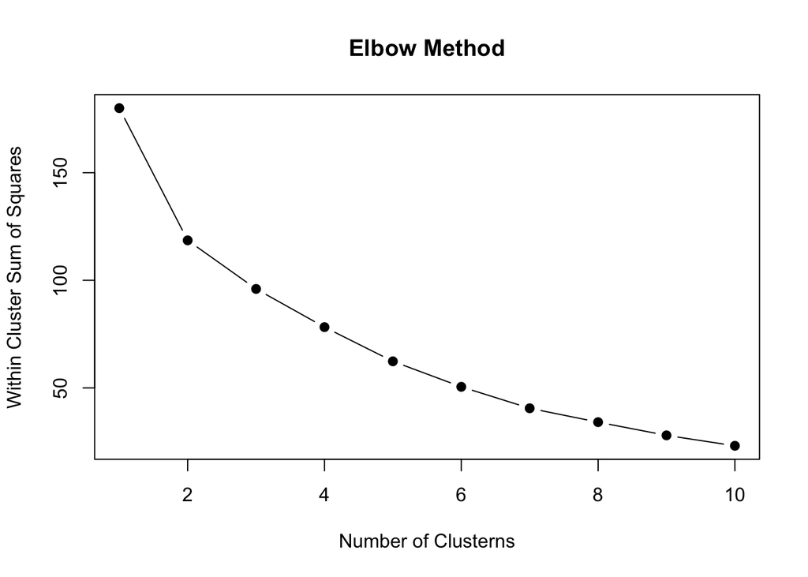

```r
set.seed(123)
wss <- numeric(10)
for(i in 1:10){wss[i] <- kmeans(mydata.scaled,centers=i,nstart=25)$tot.withinss}
plot(1:10,wss,type="b",pch=19,xlab="Number of Clusterns",ylab="Within Cluster Sum of Squares",main="Elbow Method")
```

##By looking at the elbow plot it seems like the appropriate number of clusters is 3. I say this because there is a substantial decrease when moving from one to three clusters. And also the rate of improvements diminishes beyond three clusters.

##Next I run the k-means with 3 clusters

```r
set.seed(123)
kmeans3 <- kmeans(mydata.scaled,centers=3,nstart = 25)
kmeans3
```

```
## K-means clustering with 3 clusters of sizes 4, 11, 6
##
## Cluster means:
##   Market_Cap       Beta   PE_Ratio        ROE        ROA Asset_Turnover
## 1 -0.6125361  0.2698666  1.3143935 -0.9609057 -1.0174553      0.2306328
## 2  0.6733825 -0.3586419 -0.2763512  0.6565978  0.8344159      0.4612656
## 3 -0.8261772  0.4775991 -0.3696184 -0.5631589 -0.8514589     -0.9994088
##     Leverage Rev_Growth Net_Profit_Margin
## 1 -0.3592866 -0.5757385        -1.3784169
## 2 -0.3331068 -0.2902163         0.6823310
## 3  0.8502201  0.9158889        -0.3319956
##
## Clustering vector:
##  [1] 2 1 1 2 3 1 2 3 3 2 2 3 2 3 2 2 2 1 2 3 2
##
## Within cluster sum of squares by cluster:
## [1] 20.54199 43.30886 32.14336
##  (between_SS / total_SS =  46.7 %)
##
## Available components:
##
## [1] "cluster"      "centers"      "totss"        "withinss"     "tot.withinss"
## [6] "betweenss"    "size"         "iter"         "ifault"
```

```r
kmeans3$cluster
```

```
##  [1] 2 1 1 2 3 1 2 3 3 2 2 3 2 3 2 2 2 1 2 3 2
```

```r
kmeans3$centers
```

```
##   Market_Cap       Beta   PE_Ratio        ROE        ROA Asset_Turnover
## 1 -0.6125361  0.2698666  1.3143935 -0.9609057 -1.0174553      0.2306328
## 2  0.6733825 -0.3586419 -0.2763512  0.6565978  0.8344159      0.4612656
## 3 -0.8261772  0.4775991 -0.3696184 -0.5631589 -0.8514589     -0.9994088
##     Leverage Rev_Growth Net_Profit_Margin
## 1 -0.3592866 -0.5757385        -1.3784169
## 2 -0.3331068 -0.2902163         0.6823310
## 3  0.8502201  0.9158889        -0.3319956
```

##PART A and PART B: I used the 9 numerical variables in the clustering. The variables were measured on different scales so I had to normalize the scale prior to the clustering. K-means is perfect for identiying groups with similiar characteristics especially when working with numerical data. I used the elbow method/plot to find the appropriate number of clusters. In the plot it showed a noticeable bend aorund three clusters which indicated diminishing improvements beyond that point. Because of this a three cluster solution was selected. When looking at the results, we can see that cluster 1 is made up of smaller firm with weak profitability and growth. These firms also have high valuation ratios. This cluster could be named underperforming pharmaceutical firms. Cluster 2 is comprised of profitable and large firms. These firms show strong financial performance with lower risk. I would name this cluster established industry leaders. Cluster 3 is made up of smnaller firms that are rapdily growing. They have high leverage and risk because of this growth. I would call cluster 3 something like emerging or high growth pharmaceutical firms.

##Now we need to look at how median recommednation, location, and exchange fit into these clusters.

```r
mydata$Cluster <- kmeans3$cluster
table(mydata$Cluster,mydata$Location)
```

```
##
##     CANADA FRANCE GERMANY IRELAND SWITZERLAND UK US
##   1      1      0       1       0           0  1  1
##   2      0      0       0       0           1  2  8
##   3      0      1       0       1           0  0  4
```

```r
table(mydata$Cluster,mydata$Exchange)
```

```
##
##     AMEX NASDAQ NYSE
##   1    0      0    4
##   2    0      0   11
##   3    1      1    4
```

```r
table(mydata$Cluster,mydata$Median_Recommendation)
```

```
##
##     Hold Moderate Buy Moderate Sell Strong Buy
##   1    2            1             0          1
##   2    6            3             2          0
##   3    1            3             2          0
```

##Part C ##Location: Clusters 2 and 3 were dominated by U.S based firms. Cluster 1 had a little more of a international mix of companies from Canada and Germany. There was really no strong geographic pattern that was observed. ##Exchange: Stock exchange really didnt appear to be a major factor distinguishing the clusters. The NYSE dominates in all clusters basically.

## Median Recommendation: Cluster 1 contained a strong buy recommendation. Clusters 2 and 3 contained mostly hold and moderate buy recommendations.

##Part D ## Cluster 1 should be named underperforming high valuation firms. Cluster 2 should be named established pharmacuetical leaders and cluster 3 should be named high growth or emerging pharmaceutical firms.

##Final Conclusion: Cluster 1 should be named underperforming high valuation firms because these firms have low profitability, growth, and are smaller than average. They have high price to earnings ratios which typically means investors expect positive things about the future depsite weaker current performance. Cluster 2 is the established pharmaceutical leaders and this cluster contains large firms with the most profitability. These companies have strong returns on both equity and assets. They also have high profit margins and low risk. This makes them the strongest group financially. Lastly, cluster 3 or known as the high growth emerging pharmacuetical firms is a cluster made up of smaller and riskier firms that demonstrate high growth.